# Cats and Dogs Classification

#### Import necessary libraries.

```python
import os
import keras
import numpy as np
import glob
from PIL import Image
from sklearn.model_selection import train_test_split
from keras.layers import Input, Dense, Conv2D, BatchNormalization, Activation, Flatten, MaxPool2D
from keras.models import Model
import matplotlib.pyplot as plt
```

#### The images 'images_dir' folder. The data can be downloaded from https://www.kaggle.com/c/dogs-vs-cats/data

```python
IMG_DIR = "./images_dir/"
IM_WIDTH = 128
IM_HEIGHT = 128
```

#### Read all 'jpeg' files in the folder and resize them to (128, 128). The images will be converted to numpy array. The label will be taken from the filename of the image. The following function returns images and labels as list of numpy arrays.

```python
def read_images(directory, resize_to=(128, 128)):
    """
    :param directory directory from which to read the files
    :param resize_to a tuple of width, height to resize the images
    """
    files = glob.glob(directory + "*.jpg")
    images = []
    labels = []
    for f in files:
        im = Image.open(f)
        im = im.resize(resize_to)
        im = np.array(im) / 255.0
        im = im.astype("float32")
        images.append(im)

        label = 1 if "dog" in f.lower() else 0
        labels.append(label)

    return np.array(images), np.array(labels)

X, y = read_images(directory=IMG_DIR, resize_to=(IM_WIDTH, IM_HEIGHT))
# make sure there is exact number of images in the data set.
assert len(X) == len(y) == 25000
```

#### train_test_split splits the read images into separate train and test sets. The following will split 30% of the data as test set and the rest as train set. The idea of test set is to evaluate the model on unseen data.

```python
X_train, X_test, y_train, y_test = train_test_split(X, y, test_size=0.3)
# remove X and y since we don't need them anymore
del X
del y
```

#### A method to visualize images.

```python
def plot_images(images, labels):
    n_cols = min(5, len(images))
    n_rows = len(images) // n_cols
    fig = plt.figure(figsize=(8, 8))

    for i in range(n_rows * n_cols):
        sp = fig.add_subplot(n_rows, n_cols, i+1)
        plt.axis("off")
        plt.imshow(images[i])
        sp.set_title(labels[i])
    plt.show()
```

#### Converting numeric labels to string. 'dog' if label is 1 else 'cat'.

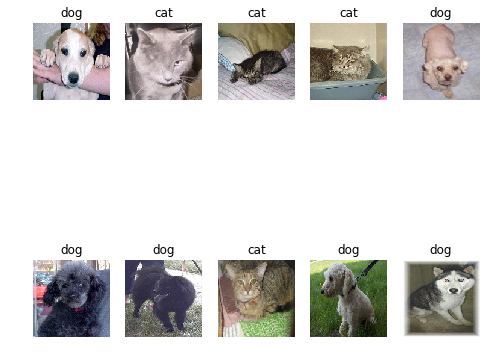

```python
def num_to_str_labels(labels):
    """
    :param labels numpy array of int
    :returns numpy array of human friendly labels
    """
    str_label =  np.where(labels == 1, "dog", "cat")
    return str_label

plot_images(X_train[:10], num_to_str_labels(y_train[:10]))
```

### Building a model

The model is built using Keras Functional API. The input layer takes an image of input shape (height x width x channel). Here, the number of channel is 3 as the images are RGB images. The output of this input layer is given as input to the convolutional layer. RELU is used as an activation function to converge faster. Batch normalization normalizes the output of previous layer by subtracting batch mean by batch standard deviation. Max pooling layer reduces the spatial dimension. Flatten layer flattens 3 dimensional data to 1 dimension. Dense layer/ Fully connected layer expects input as a 1D array and has 64 units. The final Dense layer has only 1 unit as this is a binary classification with 2 classes. Sigmoid is used as the activation function as it is between 0 and 1.

The model is defined and inputs and outputs are specified. 'adam' is used as the optimizer and 'binary-crossentropy' is used as a loss function. 'accuracy' is used as the evaluation metric.

```python
image_input = Input(shape=(IM_HEIGHT, IM_WIDTH, 3))
x = Conv2D(filters=32, kernel_size=7, activation = 'relu')(image_input)
x = BatchNormalization()(x)
x = MaxPool2D()(x)

x = Conv2D(filters=64, kernel_size=3, activation = 'relu')(x)
x = BatchNormalization()(x)
x = MaxPool2D()(x)

x = Conv2D(filters=128, kernel_size=3, activation = 'relu')(x)
x = BatchNormalization()(x)
x = MaxPool2D()(x)

x = Conv2D(filters=256, kernel_size=3, activation = 'relu')(x)
x = BatchNormalization()(x)
x = MaxPool2D()(x)

x = Flatten()(x)
x = Dense(units=64, activation = 'relu')(x)
x = BatchNormalization()(x)
x = Dense(units=1)(x)
x = Activation("sigmoid")(x)

model = Model(inputs=image_input, outputs=x)
model.compile(optimizer="adam", loss="binary_crossentropy", metrics=["accuracy"])
model.summary()
```

[output not shown]

```python
model.fit(X_train, y_train, batch_size=128, epochs=10)
```

```
<keras.callbacks.History at 0x139da927780>
```

#### The model is now trained for 10 epochs with a batch size of 128 images at a time.

#### When the model is evaluated with test set, following result is obtained.

```python
print(model.metrics_names)
model.evaluate(X_test, y_test, batch_size=128)
```

```
['loss', 'acc']
```

```
[0.39555933465957643, 0.8742666668256124]
```

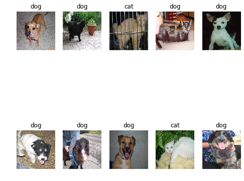

```python
predictions = model.predict(X_test)
predictions = np.where(predictions.flatten() > 0.5, 1, 0)
# plot random 20
p = np.random.permutation(len(predictions))
y_str_labels = num_to_str_labels(predictions[p[:10]])
plot_images(X_test[p[:10]], y_str_labels)
```

```python
model.save('cats_dogs.h5')
```